# Part II - (Loan Data from Prosper)

## by (Afnan Abdullah K Alshehri)

## Investigation Overview

> I would like to discover what are the major features for predicting the borrower annual percentage rate of loan in the dataset The main focus was on the amount of loan, monthly loan payment, and the characteristics of the borrowers such as their incomes and employment status.

## Dataset Overview

> This data set contains 113,937 loans with 81 variables on each loan, including loan amount, borrower rate (or interest rate), current loan status, borrower income, and many others.

## What is distribution of Borrower Annual Percentage Rate?

> Borrower APR in the dataset is approximately normally distributed with the peak around 20 percent.

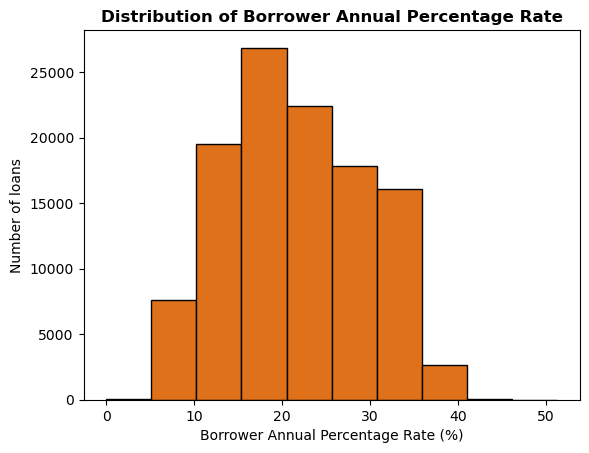

## What is relationship between the loan original amount and Borrower Annual Percentage Rate?

> • In this graph the lower the loan amount is the higher the Borrower Annual Percentage Rate.

> • Most Loan Original Amount is less than 20K.

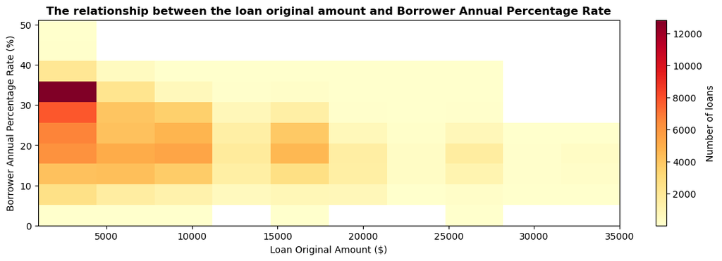

## What is the realationship between employment status and term?

> • In this plot the 36 term is the most frequent, and we find that most of the borrowers are employed in the 36 term.

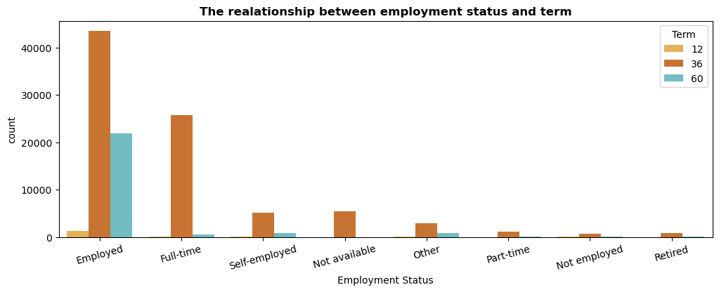

## What is the Income Range and Borrower Annual Percentage Rate across Loan Status?

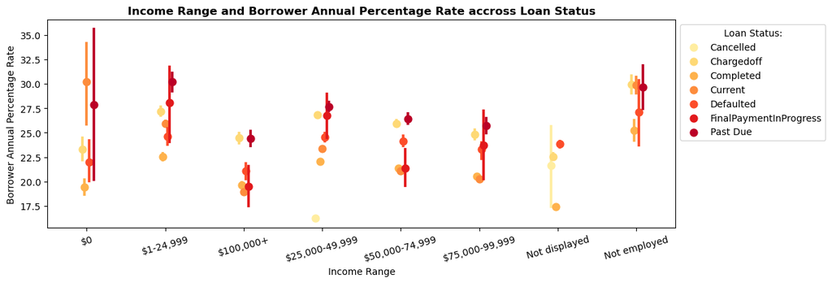